# Text clustering

Authors

Osaro Orebor 1168827

Máté Csikós-Nagy 4395565

Fani Profiti 1240390

Yara Yachnyk 4913329

Niels Wagenaar 3133998

Published

November 3, 2025

```r
data("movie_review")
movie_review <- as_tibble(movie_review)
```

```r
glimpse(movie_review) #take a quick glance at data
```

```
Rows: 5,000
Columns: 3
$ id        <chr> "5814_8", "2381_9", "7759_3", "3630_4", "9495_8", "8196_8", …
$ sentiment <int> 1, 1, 0, 0, 1, 1, 0, 0, 0, 1, 0, 1, 1, 0, 0, 0, 0, 0, 1, 1, …
$ review    <chr> "With all this stuff going down at the moment with MJ i've s…
```

```r
summary(movie_review)
```

```
      id              sentiment         review
 Length:5000        Min.   :0.0000   Length:5000
 Class :character   1st Qu.:0.0000   Class :character
 Mode  :character   Median :1.0000   Mode  :character
                    Mean   :0.5034
                    3rd Qu.:1.0000
                    Max.   :1.0000
```

```r
sapply(movie_review, class) #identify classes of dataset variables for sentiment analysis
```

```
         id   sentiment      review
"character"   "integer" "character"
```

```r
table(movie_review$sentiment) #see the distribution of negative and positive reviews
```

```
   0    1
2483 2517
```

# Data description

Based on the dataset “movie_review” embedded in text2vec package, we see the selection of positive and negative reviews of movie viewers, relatively evenly distributed in the dataset (2483 negative and 2517 positive reviews) denoted with score 1 if the IMDB rating was >= 7 or 0 if rating is <5 accordingly.

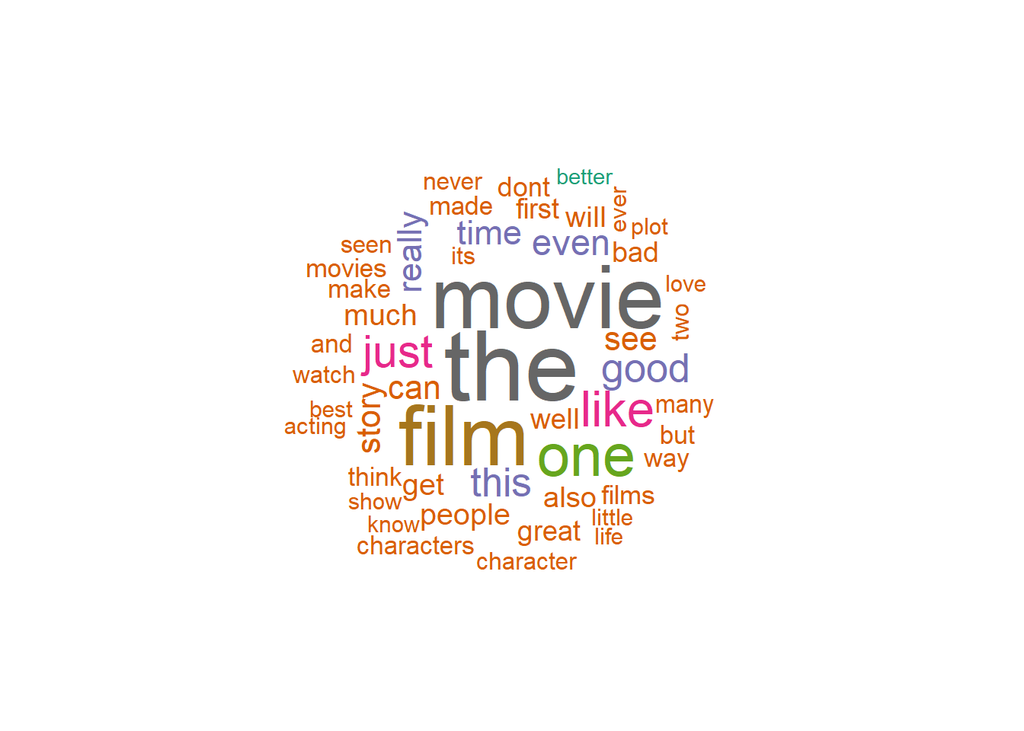

```r
# your R code to generate the plot here
movie_review %$% wordcloud(review,
                           min.freq = 10,
                           max.words = 50,
                           random.order = FALSE,
                           colors = brewer.pal(8, "Dark2"))
```

# Text pre-processing

### Train test split

Before starting text pre-processing steps, we first need to split the train dataset to a sample used for training, a sample used for validation during training and a test sample to check performance after the training is done. We have decided to split the train data 80:10:10 (training: validation: testing)

```r
split_movie_dataset <- function (movie_review, sentiment = "sentiment"){

      # set seed for reproducibility
      set.seed(123)

      #first split the full data set in a 80/20 test train set then split the test val data 50/50 so they both become 10% of the full dataset
      train_split <- sample.split(movie_review$sentiment, SplitRatio = 0.8)
      val_split <- sample.split(movie_review$sentiment[!train_split], SplitRatio = 0.5)

      # save the row indices that are part of the set
      train_ids <- which(train_split)
      temp_ids <- which(!train_split)
      val_ids <- temp_ids[val_split]
      test_ids <- temp_ids[!val_split]

      # return final datasets
      return(list(
          train_set = movie_review[train_ids, ],
          test_set = movie_review[test_ids, ],
          val_set = movie_review[val_ids, ]
      ))
}

data_splits <- split_movie_dataset(movie_review = movie_review)
train_set <- data_splits$train_set
val_set <- data_splits$val_set
test_set <- data_splits$test_set
```

```r
train_set$sentiment <- as.factor(train_set$sentiment)
sapply(train_set, class) #checking the factor change
```

```
         id   sentiment      review
"character"    "factor" "character"
```

```r
train_set <- train_set %>%
  filter(!is.na(review)) %>%
  distinct(review, .keep_all = T)
```

Now, we will lowercase all the letters in the texts:

```r
clean_train_set <- train_set %>%
  mutate(review = review %>%
      str_to_lower() %>% # induce lowercase
  str_squish()) #remove extra space
```

Next, we will tokenize review column:

```r
clean_train_set <- clean_train_set |>
  unnest_tokens(word, review)
```

We then received 967628 observations from 3997 reviews; now let’s see the most common words from our reviews (we use ggplot function):

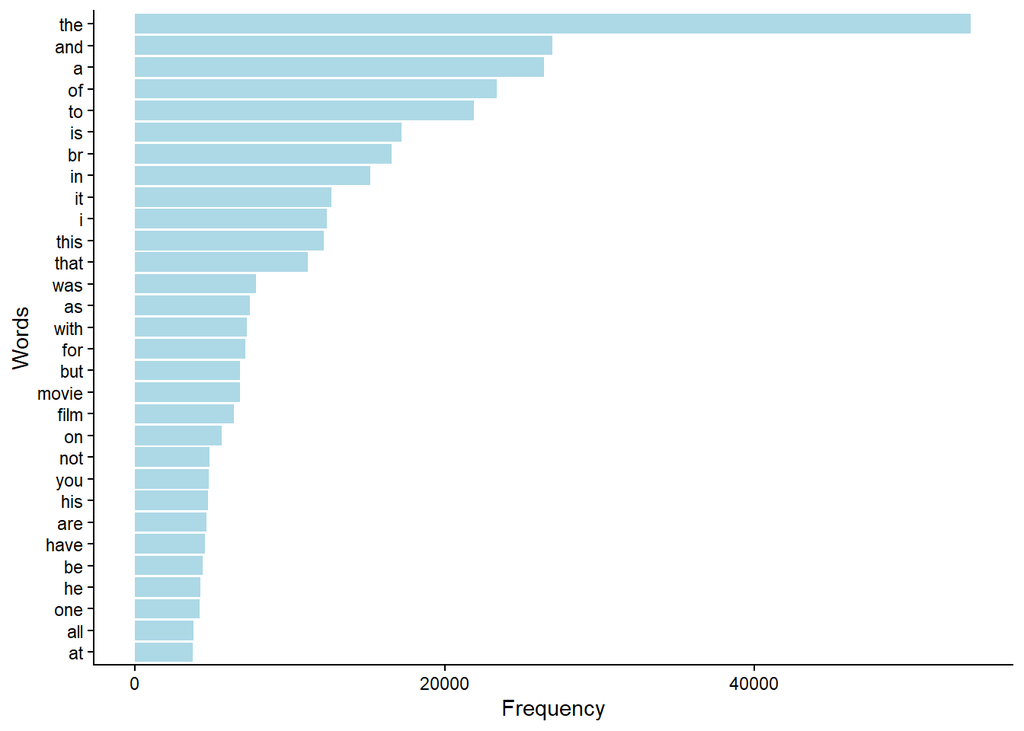

```r
clean_train_set %>%
  mutate(word = as.character(word)) %>%
  dplyr::count(word) %>%              # force dplyr version
  arrange(desc(n)) %>%                # manually sort
  head(30) %>%
  ggplot(aes(x = n, y = reorder(word, n))) +
  geom_col(fill = "lightblue") +
  labs(x = "Frequency", y = "Words") +
  theme_classic()
```

We see that many of the top words can be considered “stop words” since they bring no significant importance to review meanings, let’s remove stop words(except for not because then we can imply window context words to identify negative or positive meanings of bigger phrases:

```r
stop_words <- c(
  "the", "and", "a", "of", "to", "is", "it", "in", "this", "that", "was",
  "as", "with", "for", "movie", "but", "film", "you", "he", "his", "are", "have", "be", "one"
)
stop_words <- tibble(word=stop_words)
  clean_train <- clean_train_set %>%
    anti_join(stop_words, by = "word")
```

Eventually, we are left with 663508 observations. Let’s see our top words now:

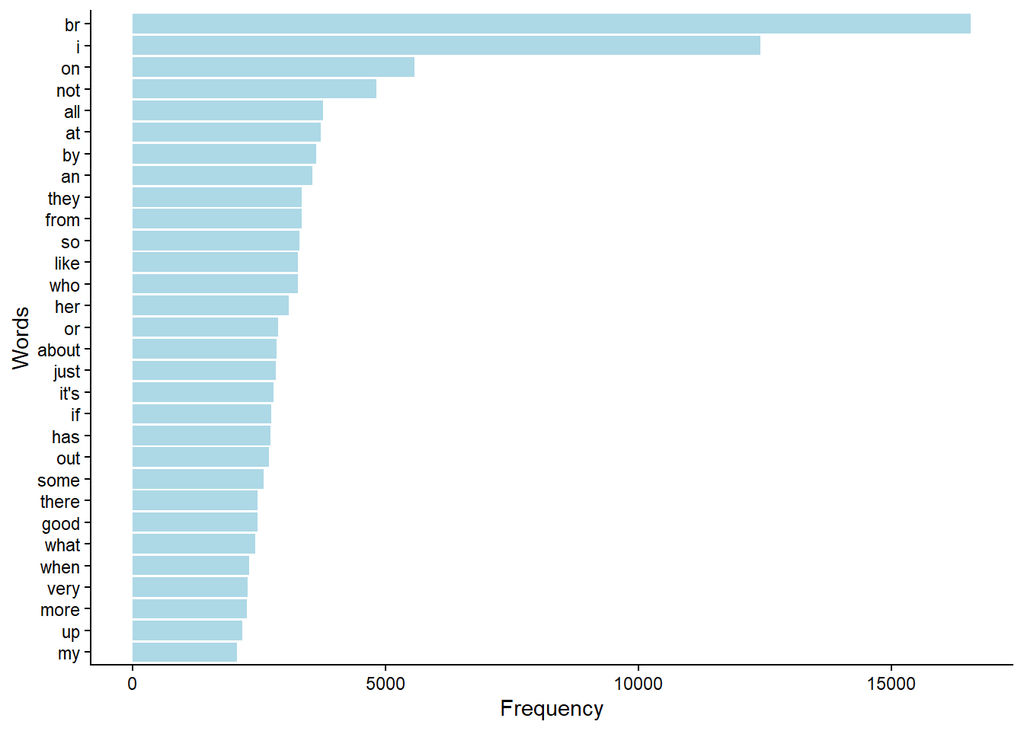

```r
clean_train %>%
  mutate(word = as.character(word)) %>%      # ensure character (not a list)
  dplyr::count(word, name = "n") %>%         # count words
  arrange(desc(n)) %>%                       # sort by frequency
  slice_head(n = 30) %>%                     # keep top 30
  ggplot(aes(x = n, y = fct_reorder(word, n))) +
  geom_col(fill = "lightblue") +
  labs(x = "Frequency", y = "Words") +
  theme_classic()
```

There are still some stop words left, and removing them all manually might be time-consuming. Let’s instead use the dataset `smart_stopwords` from `library(stopwords)` and modify it with those words that we want to use in the analysis(for example, leaving negative particles to see the negative review sensitivity). We will also add words to the “stoplist” that don’t make sense for our analysis or neutral movie words that don’t have sentimental signal:

```r
smart_stopwords <- stopwords(source = "smart")
stop_words <- tibble(word=smart_stopwords)
df_stopwords <- stop_words %>%
  filter(!word %in% c("neither", "never", "no", "nobody", "non", "none", "not", "nothing", "nowhere", "awfully", "best", "better", "cannot", "least", "less", "like", "little", "serious", "thanks", "welcome", "want", "willing", "will", "wish", "without")) %>%
  rbind(tibble(word = c("br", "made", "make", "movie", "film", "films", "movies", "story", "plot",
  "character", "characters", "people", "show", "watch",
  "life", "scene", "end", "man", "time")))
#removing stop words
  clean_train <- clean_train_set %>%
    anti_join(df_stopwords, by = "word")
```

In the end, we received 384141 observations to work with.

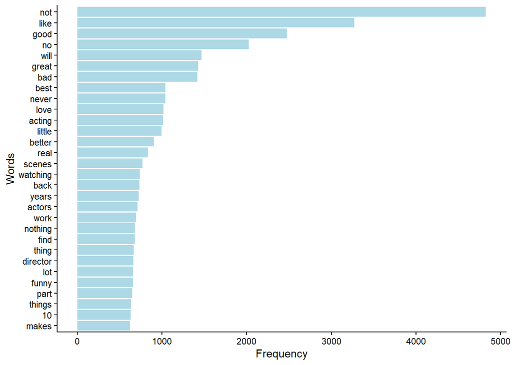

```r
# if 'word' is a list (e.g., each cell has a length-1 character), flatten it safely
clean_train <- clean_train %>%
  mutate(word = if (is.list(word)) purrr::map_chr(word, 1) else as.character(word))

clean_train %>%
  dplyr::count(word, name = "n") %>%   # force dplyr's count
  arrange(desc(n)) %>%
  slice_head(n = 30) %>%
  ggplot(aes(x = n, y = fct_reorder(word, n))) +
  geom_col(fill = "lightblue") +
  labs(x = "Frequency", y = "Words") +
  theme_classic()
```

```r
smart_stopwords <- stopwords(source = "smart")
stop_words <- tibble(word=smart_stopwords)
df_stopwords <- stop_words %>%
  rbind(tibble(word = c(
    # --- Woorden van vorige iteraties ---
    "br", "made", "make", "movie", "film", "films", "movies", "story",
    "plot", "character", "characters", "people", "show", "watch",
    "life", "scene", "end", "man", "time", "years", "world", "book",
    "good", "bad", "like", "great", "best", "better", "little", "pretty",
    "acting", "actors", "love", "funny", "watching", "real", "horror",
    "thing", "things", "lot", "work", "scenes", "part", "find", "back",
    "role", "big", "original", "cast", "10", "give", "action", "minutes",
    "thought", "point", "fact", "making", "long", "war", "family",
    "young", "series", "performance", "makes", "feel", "woman",
    "excellent", "times", "girl", "played", "comedy", "music",
    "director", "actor", "left", "guy", "father", "american", "hard", "play",
    "2", "game", "night", "1", "match", "kind", "house", "bit", "true",
    "script", "men", "wife", "day", "stewart", "shows"
  )))

clean_docs_data <- function (data, df_stopwords){

    cleaned_docs <- data %>%
        # First, we will change sentiment column to factor class:
        mutate(sentiment = as.factor(sentiment)) %>%

        # Next, we will remove empty rows with no text or duplicates, which leaves us with 4996 observations.
        dplyr::filter(!is.na(review)) %>%
        distinct(review, .keep_all = T) %>%

        # We will lowercase all the letters in the texts:
        mutate(review = review %>%
          str_to_lower() %>% # induce lowercase
          str_squish()) %>%  # remove extra space

        # Next, we will tokenize review column:
        unnest_tokens(word, review) %>%

        # Removing stop words
        anti_join(df_stopwords, by = "word") %>%

        # Recombining words into reviews for the DTM
        group_by(id) %>%
        summarize(review = paste(word, collapse = " ")) %>%
        ungroup()

    return(cleaned_docs)

}

train_docs <- clean_docs_data(data = data_splits$train_set, df_stopwords)
val_docs <- clean_docs_data(data = data_splits$val_set, df_stopwords)
test_docs <- clean_docs_data(data = data_splits$test_set, df_stopwords)
```

# Text representaion

For the text representation method we selected DTM (Document-Term Matrix). In a document term matrix the rows correspond to the documents in the corpus (in our case the movie reviews) and the columns correspond to the terms in the documents (in our case the cleaned words of the reviews). The cell values are the frequency of the given word in the given document.The resulting matrix is typically very sparse, since most words appear only in a few documents.

Before creating the DTM, we also filter out infrequent terms using `term_count_min=5`, which removes words that occur fewer than 5 times in the entire corpus. This reduces noise and makes the DTM faster to process.

```r
build_dtm_parts <- function(docs, term_count_min = 5){
    # create index-tokens
    it <- itoken(docs$review, progressbar = FALSE)

    # collecting unique terms
    vocab <- create_vocabulary(it)

    # filtering infrequent terms
    vocab <- prune_vocabulary(vocab, term_count_min)

    # creating the vectorizer
    vectorizer <- vocab_vectorizer(vocab)

    # creating document term matrix
    dtm <- create_dtm(it, vectorizer)

    return(list(
            dtm = dtm,
            vocab = vocab,
            vectorizer = vectorizer
            ))
}

dtm_parts <- build_dtm_parts(train_docs)
dtm <- dtm_parts$dtm
vocab <- dtm_parts$train
vectorizer <- dtm_parts$vectorizer
dtm_matrix <- as.matrix(dtm)
```

# Text clustering

## K-MEANS CLUSTERING

K- means clustering is an unsupervised machine learning algorithm and shows which data points are similar based to their distance. The closer together are the data points the more similar they are. The clusters are created by assigning each data point to the nearest centroid, then iteratively the centroids are calculated again until the clusters stabilize.

```r
k_means_clustering <- function (dtm_matrix, k, seed = 123){

    set.seed(seed)
    km <- kmeans(dtm_matrix, centers = k)

    return(list(
    km = km,
    clusters = km$clusters
    ))
}
kmeans_k5 <- k_means_clustering(
    dtm_matrix = dtm_matrix,
    k = 5
    )
kmeans_k10 <- k_means_clustering(
    dtm_matrix = dtm_matrix,
    k = 10
    )
```

## LDA

```r
lda_model <- function(dtm, k, seed = 123) {
  row_sums <- Matrix::rowSums(dtm)
  non_empty_rows <- which(row_sums > 0)
  dtm_filtered <- dtm[non_empty_rows, ]
  set.seed(seed)
  lda_model <- LDA(
    dtm_filtered,
    k = k,
    method = "Gibbs",
    control = list(seed = seed)
  )
  return(lda_model)
}



lda_model_k5 <- lda_model(
    dtm,
    k = 5
    )
lda_model_k10 <- lda_model(
    dtm,
    k = 10
    )
```

## LSA

```r
lsa_kmeans <- function(dtm, k, n_topics, seed = 123, nstart = 25){

    lsa_model <- LSA$new(n_topics = n_topics)
    doc_vecs_lsa <- lsa_model$fit_transform(dtm)

    set.seed(seed)
    kmeans <- kmeans(
        as.matrix(doc_vecs_lsa),
        centers = k,
        nstart = nstart
    )
    return(list(
        kmeans = kmeans,
        clusters = kmeans$clusters,
        lsa_matrix = doc_vecs_lsa
    ))
}

lsa_kmeans_k5 <- lsa_kmeans(
  dtm = dtm_matrix,
  k = 5,
  n_topics = 100
)

lsa_kmeans_k10 <- lsa_kmeans(
  dtm = dtm_matrix,
  k = 10,
  n_topics = 100
)
```

## NMF

Non-Negative Matrix Factorization works by decomposing a matrix into two smaller matrices W and H, so that W * H approximates the original matrix. In our case, W will be the document-topic matrix (rows will be the documents and columns are the “topics” or clusters), and H will be the topic-term matrix (rows the topics and columns the words). Each entry in W indicates the strength of association between a document and a topic and each entry in H indicates the importance of a term for a given topic.

Since all the values are non-negative, NMF produces representations that work with additions (for instance, topics are combinations of words), so the result is easy to interpret.

```r
# Running the models
nmf_res_5 <- nmf(dtm_matrix, k = 5, seed = 123)
```

```
iter |      tol
---------------
   1 | 6.78e-01
   2 | 1.58e-01
   3 | 2.67e-01
   4 | 2.42e-02
   5 | 1.88e-03
   6 | 2.53e-03
   7 | 7.89e-03
   8 | 1.41e-02
   9 | 6.68e-03
  10 | 1.19e-03
  11 | 2.27e-04
  12 | 9.51e-05
```

```r
nmf_res_10 <- nmf(dtm_matrix, k = 10, seed = 123)
```

```
iter |      tol
---------------
   1 | 6.72e-01
   2 | 2.47e-01
   3 | 9.10e-02
   4 | 4.03e-02
   5 | 1.17e-02
   6 | 4.83e-03
   7 | 2.91e-03
   8 | 1.85e-03
   9 | 1.28e-03
  10 | 9.83e-04
  11 | 7.32e-04
  12 | 5.05e-04
  13 | 3.12e-04
  14 | 2.06e-04
  15 | 1.60e-04
  16 | 1.55e-04
  17 | 1.73e-04
  18 | 1.97e-04
  19 | 2.18e-04
  20 | 2.33e-04
  21 | 2.42e-04
  22 | 2.37e-04
  23 | 2.06e-04
  24 | 1.88e-04
  25 | 1.69e-04
  26 | 1.44e-04
  27 | 1.03e-04
  28 | 7.48e-05
```

```r
# Document topic matrix
W_5 <- nmf_res_5$w
W_10 <- nmf_res_10$w

# Topic-term matrix
H_5 <- nmf_res_5$h
H_10 <- nmf_res_10$h

# Assigning each document to the topic with the highest weight
nmf5_clusters <- apply(W_5, 1, which.max)
nmf10_clusters <- apply(W_10, 1, which.max)
```

# Evaluation & model comparison

To compare the clustering methods, we used two internal validation metrics: the Silhouette score and the Davies–Bouldin Index (DB Index). These metrics evaluate how well the data points fit within their assigned clusters and how clearly the clusters are separated, without relying on any external labels. The Silhouette score measures how similar each document is to its own cluster compared to other clusters, while the DB Index captures how compact and distinct the clusters are from one another.

We chose these metrics because they capture a different aspect of clustering quality. The Silhouette score shows how well-separated and consistent the clusters are, making it a good overall measure of cluster structure. The DB Index was added as a second internal metric because it focuses on how compact and distinct the clusters are, helping confirm the Silhouette results.

```r
# helper functions
sil_medoid_mean <- function(X, centers) {
  D_obs_centers <- proxy::dist(X, centers, method = "cosine")
  Silhouette(D_obs_centers, method = "medoid")$sil_width |> mean(na.rm = TRUE)
}

centroids_from_labels <- function(X, clusters) {
  cs <- sort(unique(clusters))
  do.call(rbind, lapply(cs, function(c) colMeans(X[clusters == c, , drop = FALSE])))
}

# use the models we  trained
X_counts <- dtm_matrix
km5_clusters  <- kmeans_k5$km$cluster
km10_clusters <- kmeans_k10$km$cluster
km5_centers   <- kmeans_k5$km$centers
km10_centers  <- kmeans_k10$km$centers

X_lsa5  <- as.matrix(lsa_kmeans_k5$lsa_matrix)
X_lsa10 <- as.matrix(lsa_kmeans_k10$lsa_matrix)
lsa5_clusters <- lsa_kmeans_k5$kmeans$cluster
lsa10_clusters <- lsa_kmeans_k10$kmeans$cluster
lsa5_centers  <- lsa_kmeans_k5$kmeans$centers
lsa10_centers <- lsa_kmeans_k10$kmeans$centers

doc_topic5  <- posterior(lda_model_k5)$topics
doc_topic10 <- posterior(lda_model_k10)$topics
lda5_clusters  <- max.col(doc_topic5,  ties.method = "first")
lda10_clusters <- max.col(doc_topic10, ties.method = "first")
lda5_centers   <- centroids_from_labels(doc_topic5,  lda5_clusters)
lda10_centers  <- centroids_from_labels(doc_topic10, lda10_clusters)

X_nmf5 <- W_5
X_nmf10 <- W_10
nmf5_centers  <- centroids_from_labels(X_nmf5, nmf5_clusters)
nmf10_centers <- centroids_from_labels(X_nmf10, nmf10_clusters)

# silhouette scores (higher = better)
sil_km5   <- sil_medoid_mean(X_counts, km5_centers)
sil_km10  <- sil_medoid_mean(X_counts, km10_centers)
sil_lsa5  <- sil_medoid_mean(X_lsa5,  lsa5_centers)
sil_lsa10 <- sil_medoid_mean(X_lsa10, lsa10_centers)
sil_lda5  <- sil_medoid_mean(doc_topic5,  lda5_centers)
sil_lda10 <- sil_medoid_mean(doc_topic10, lda10_centers)
sil_nmf5  <- sil_medoid_mean(X_nmf5, nmf5_centers)
sil_nmf10 <- sil_medoid_mean(X_nmf10, nmf10_centers)

# DB index (lower = better)
db_km5   <- index.DB(X_counts, km5_clusters,  centrotypes = "centroids")$DB
db_km10  <- index.DB(X_counts, km10_clusters, centrotypes = "centroids")$DB
db_lsa5  <- index.DB(X_lsa5,  lsa5_clusters,  centrotypes = "centroids")$DB
db_lsa10 <- index.DB(X_lsa10, lsa10_clusters, centrotypes = "centroids")$DB
db_lda5  <- index.DB(doc_topic5,  lda5_clusters,  centrotypes = "centroids")$DB
db_lda10 <- index.DB(doc_topic10, lda10_clusters, centrotypes = "centroids")$DB
db_nmf5  <- index.DB(X_nmf5, nmf5_clusters, centrotypes = "centroids")$DB
db_nmf10 <- index.DB(X_nmf10, nmf10_clusters, centrotypes = "centroids")$DB

# final results table
results <- tibble::tibble(
  model = c("K-Means (k=5)", "K-Means (k=10)",
            "LSA + K-Means (k=5)", "LSA + K-Means (k=10)",
            "LDA (k=5)", "LDA (k=10)",
            "NMF (k=5)", "NMF (k=10)"),
  silhouette = c(sil_km5, sil_km10,
                 sil_lsa5, sil_lsa10,
                 sil_lda5, sil_lda10,
                 sil_nmf5, sil_nmf10),
  db_index   = c(db_km5, db_km10,
                 db_lsa5, db_lsa10,
                 db_lda5, db_lda10,
                 db_nmf5, db_nmf10)
)

results
```

| model | silhouette | db_index |
| --- | --- | --- |
| K-Means (k=5) | 0.0141481 | 8.778879 |
| K-Means (k=10) | 0.0181457 | 5.861358 |
| LSA + K-Means (k=5) | 0.0619391 | 2.976287 |
| LSA + K-Means (k=10) | 0.0523021 | 3.199632 |
| LDA (k=5) | 0.6100236 | 1.201022 |
| LDA (k=10) | 0.5022152 | 1.506388 |
| NMF (k=5) | 0.6884335 | 10.250386 |
| NMF (k=10) | 0.5600771 | 9.572809 |

# Team member contributions